# Analysis of the Predator-Prey System

# Rabbits and Foxes

We will now apply our machinery to the predator-prey system. Consider the rabbits and foxes example from a few days ago, with simple choices of parameters shown below.
$$\begin{align*}
\frac{df}{dt} &= -3f + rf\\
\frac{dr}{dt} &= 4r - 2 rf
\end{align*}$$
In your homework you just found the nullclines, which hopefully looked like this:

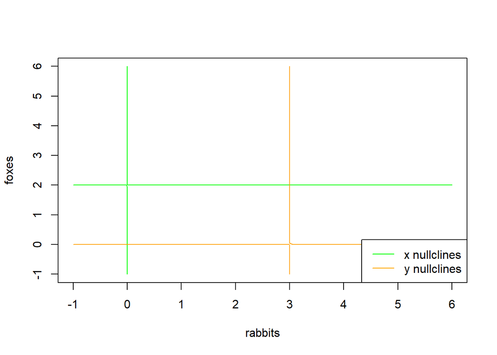

In this picture, the $x$-nullclines are for rabbits, and the $y$-nullclines are for foxes.

Now we ask the computer to make a direction field on top of the nullclines. It will look like this.

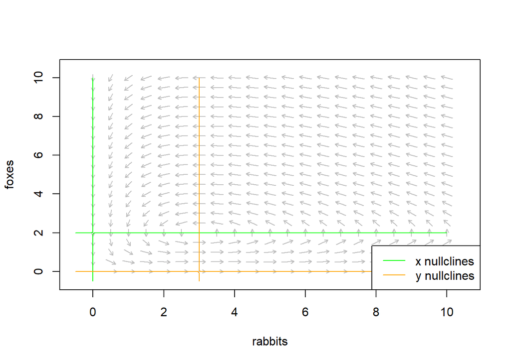

Let’s practice reading information from this picture.

1. The most striking feature is that the arrows form large swirls. This means we expect solutions to be *periodic*, meaning our populations will oscillate.
2. There are two equilibria: one at $(0,0)$ and one at $(3,2)$. (We can pretend that we measure animals in hundreds, so this might mean 300 rabbits and 200 foxes.)
3. Along an $x$-nullclines, the vectors only point up/down. Also, along $y$-nullclines, the vectors only point left/right.

Let’s look at a trajectory starting from $(6,5)$.

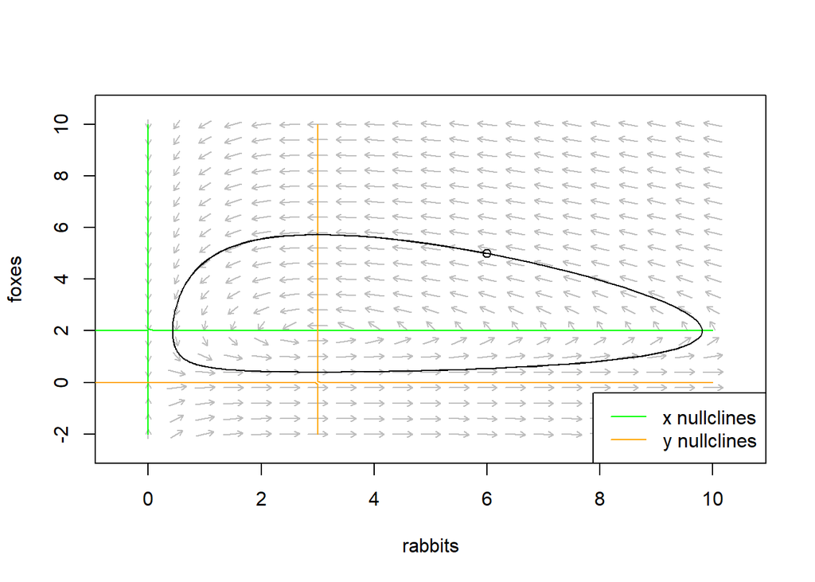

The fact that the trajectory cycles back on itself (we call this “closing up”) means that in this model, this behaviour cycles on forever.

### Example: sketch the functions $r(t)$ and $f(t)$ for the trajectory above.

We can do this by hand and get it almost correct, but a computer can give us the accurate functions of time. Here is what they look like.

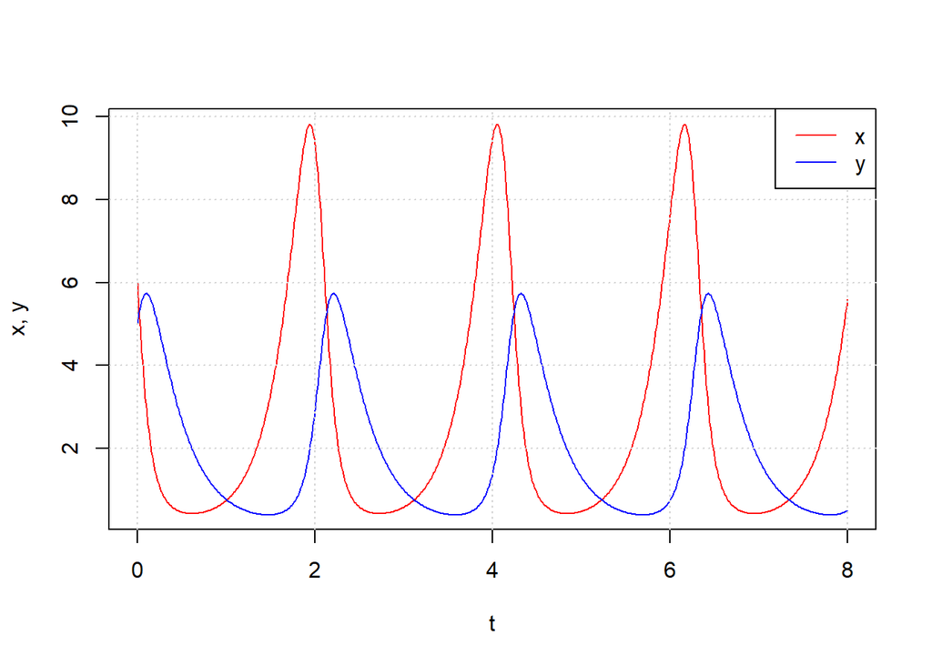

By looking at these (computer) made graphs, we should notice some aspects:

1. The solutions are periodic: they repeat every so often. (They are not trig functions, however!)
2. The prey populations spike before the predators do.
3. Notice the importance of where features happen is important. For instance, if we moved the blue graph to the left some and kept the red one where it is, then it would no longer represent a solution! The differential equations actually told us the correct locations for the peaks and troughs of our populations.

### Example: deciding which graph is which

Given the two graphs $x(t)$ and $y(t)$ shown below, which represents the predator population, and which is the prey? Bonus question: do these populations seem to be sustainable?

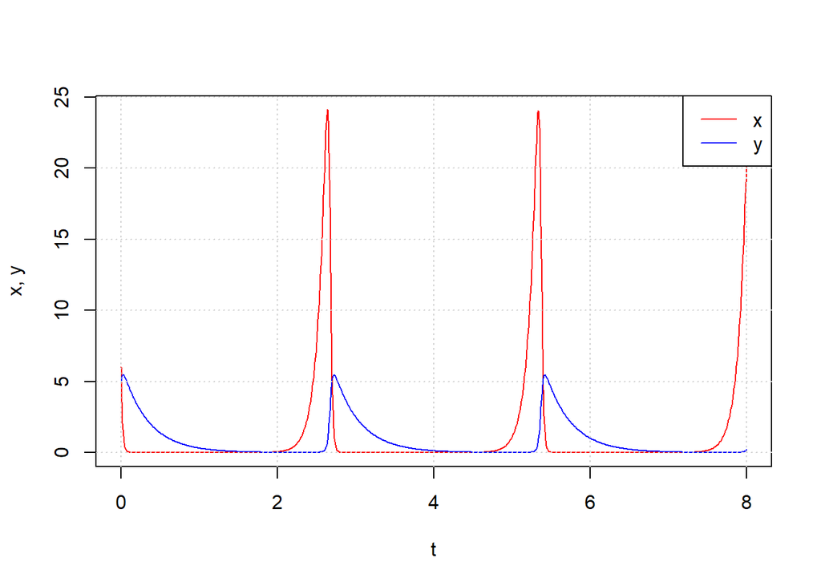

We know that in a predator prey model, the prey population spikes before the predators.

A word of Caution. Just because the arrows form swirls does *not necessarily* mean that solutions *will* be periodic. Here’s an example of a direction field that looks similar, but the solutions spiral instead of stay consistent.

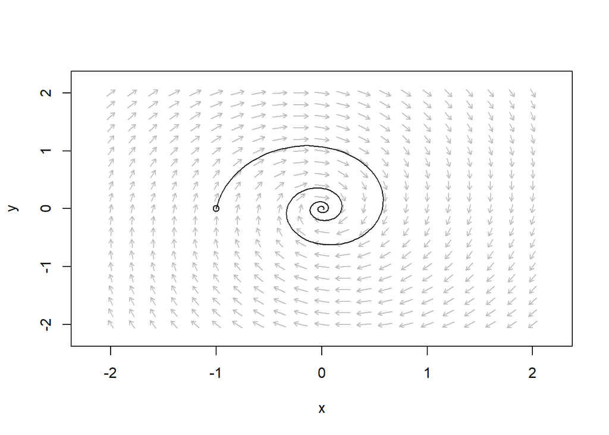

This is for the system we saw yesterday, which was
$$\begin{align*}
\frac{dx}{dt} = -x + 4y \\
\frac{dy}{dt} = -y - 4x
\end{align*}$$

# Questions I might ask you

## Decide which population is which, and discussion of the behaviour of the populations.

1. Given the graphs of two solutions below, which is the predator population, and which is the prey? Describe the dynamics of these two populations.

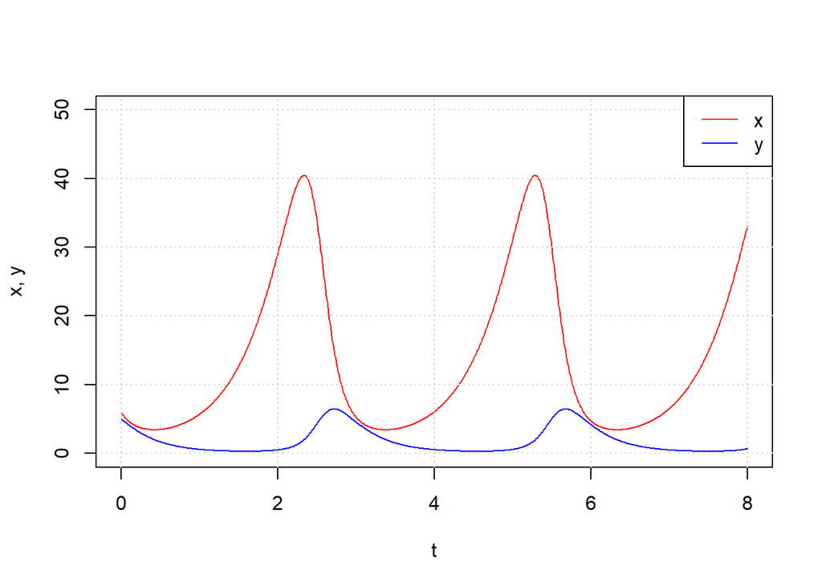

### Dynamics from the phase plane trajectory.

2. Given the trajectories below, describe the dynamics of the populations over one time cycle. Does it look like one population might die out? Are these populations able to thrive in the long run?

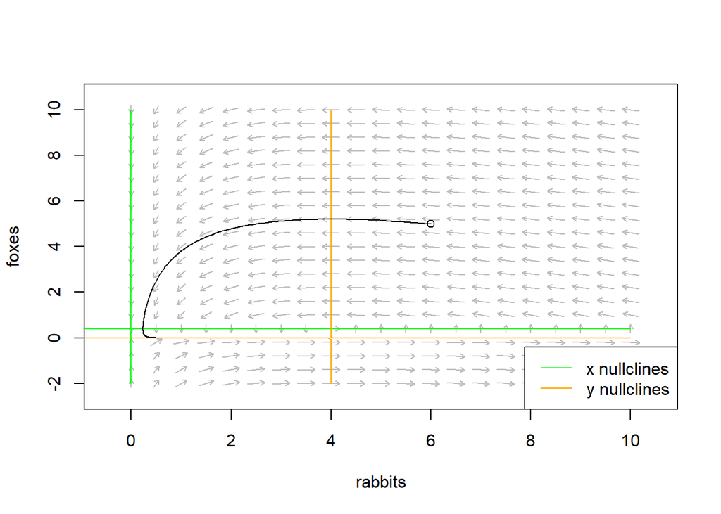

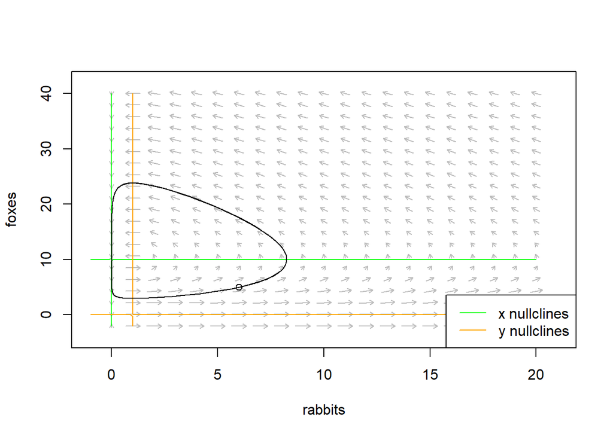